# Task 11

Aina Petronytė

2016 m lapkritis 10 d

## Task 11

Užduočiai naudojamas duomenų masyvas longley iš paketo datasets:

```r
library("datasets")
data <- longley
head(longley)
```

```
##      GNP.deflator     GNP Unemployed Armed.Forces Population Year Employed
## 1947         83.0 234.289      235.6        159.0    107.608 1947   60.323
## 1948         88.5 259.426      232.5        145.6    108.632 1948   61.122
## 1949         88.2 258.054      368.2        161.6    109.773 1949   60.171
## 1950         89.5 284.599      335.1        165.0    110.929 1950   61.187
## 1951         96.2 328.975      209.9        309.9    112.075 1951   63.221
## 1952         98.1 346.999      193.2        359.4    113.270 1952   63.639
```

Iš duomenų masyvo kintamųjų GNP ir Employed sukuriamas tiesinės regresijos modelis, prognozuojamas kintamasis - GNP:

```r
GNP <- data$GNP
employed <- data$Employed
ties.reg = lm(GNP~employed)
```

Toliau pateikiamas modelio apibendrinimas:

```r
summary(ties.reg)
```

```
##
## Call:
## lm(formula = GNP ~ employed)
##
## Residuals:
##     Min      1Q  Median      3Q     Max
## -39.223 -11.920   0.855  14.882  23.555
##
## Coefficients:
##              Estimate Std. Error t value Pr(>|t|)
## (Intercept) -1430.482     89.361  -16.01 2.15e-10 ***
## employed       27.836      1.366   20.37 8.36e-12 ***
## ---
## Signif. codes:  0 '***' 0.001 '**' 0.01 '*' 0.05 '.' 0.1 ' ' 1
##
## Residual standard error: 18.58 on 14 degrees of freedom
## Multiple R-squared:  0.9674, Adjusted R-squared:  0.965
## F-statistic: 415.1 on 1 and 14 DF,  p-value: 8.363e-12
```

Tiesinės regresijos modelio Residuals rodo duomenų pasklidimo apie regresijos tiesę charakteristikas - minimumą, pirmąjį kvartilį, medianą, trečiąjį kvartilį ir maksimumą. Coefficients stulpelis Estimate parodo lygties koeficientų $\beta$<sub>0</sub> ir $\beta$<sub>1</sub> įverčius: $\beta$<sub>0</sub> = -1430.482, $\beta$<sub>1</sub> = 27.836. $\beta$<sub>0</sub> reikšmė yra vidutinis GNP, kai Employed = 0, šie duomenys gali būti neteisingi, nes duomenų masyve mažiausia Employed reikšmė buvo virš 60. $\beta$<sub>1</sub> yra vidutinio GNP didėjimas, kai vienetu didėja Employed. Stulpelis Std. Error parodo šių įverčių standartinius nuokrypius, t value parodo Stjudento kriterijaus t reikšmę, o Pr(>|t|) - reikšmingumo lygmenis, iš kurių galima spręsti, kad koeficientai reikšmingai skiriasi nuo nulio.

Toliau randamos modelio prognozuojamos reikšmės taškuose 62, 65 ir 68:

```r
prog = predict(ties.reg, newdata=data.frame(employed=c(62, 65, 68)))
prog
```

```
##        1        2        3
## 295.3656 378.8743 462.3831
```

Braižoma kintamųjų sklaidos diagrama su tiesinės regresijos tiese ir naujomis prognozėmis:

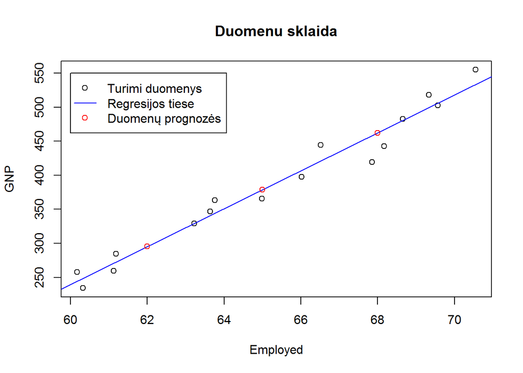

```r
plot(employed, GNP, xlab='Employed', ylab='GNP', main='Duomenu sklaida')
abline(ties.reg, col='blue')
points(c(62, 65, 68), prog, col='red')
legend(60, 550, c("Turimi duomenys", "Regresijos tiese", "Duomenų prognozės"), lty=c(0,1,0), pch=c(1,NA,1), col=c("black", "blue", "red"))
```

Šaltiniai:

Kerns, G. Jay. 2011. “Introduction to Probability and Statistics Using R.”

Dependent and independent variables, Wikipedia https://en.wikipedia.org/wiki/Dependent_and_independent_variables

Simple Linear Regression by Ralph, R-bloggers, 2010 https://www.r-bloggers.com/simple-linear-regression-2/